# Untitled

```r
library(dplyr)


DF <- ChickWeight %>%
  filter(Diet %in% c(3,4))

DF

DF %>%
  group_by(Diet) %>%
  summarise(mean(weight), var(weight), n())



t.test(weight~Diet, data=DF)
```

if p < alpha (defaul to 0.05), reject the null hypo reject null, or fail to reject. no confirming conclusion always in terms of alt hypo

type 1 error: reject h0 when h0 is true type 2 error: fail to reject h0 when h0 is false

# GGPLOT ———————————————-

- boxplot
- bargraph
- jitter/point

# BINOM ————————————————–

#### * Generate 100 occurrences of flipping 10 coins, each with 30% probability

rbinom(100, 10, .3) rbinom(# of repeats, # of flips, % chance)

#### * Calculate the probability that 2 are heads using dbinom

```
dbinom(2, 10, .3)
dbinom(# equal to heads, # of flips, % chance)

  equivalent to:
   Confirm your answer with a simulation using rbinom
  mean(rbinom(10000, 10, .3) == 2)
```

#### * Calculate the probability that at least five coins are heads

1 - pbinom(4, 10, .3) pbinom(# <= heads, # of flips, % chance)

```
  equivalent to:
   Confirm your answer with a simulation of 10,000 trials
  mean(rbinom(10000, 10, .3) >= 5)
```

#### * Simulate 100,000 flips of a coin with a 40% chance of heads

A <- rbinom(100000, 1, .4)

Simulate 100,000 flips of a coin with a 20% chance of heads B <- rbinom(100000, 1, .2)

Estimate the probability both A and B are heads mean(A & B)

# PVALUE —————————————————

```
the probability that you observe a value as extreme as ___ based on the null hypothesis being true.
if p < alpha, reject null.
if p > alpha, fail to reject null

if alt hypotheseis is 2 sided (!=), must multiply p value by 2
```

# RANDOM NOTES———————————————–

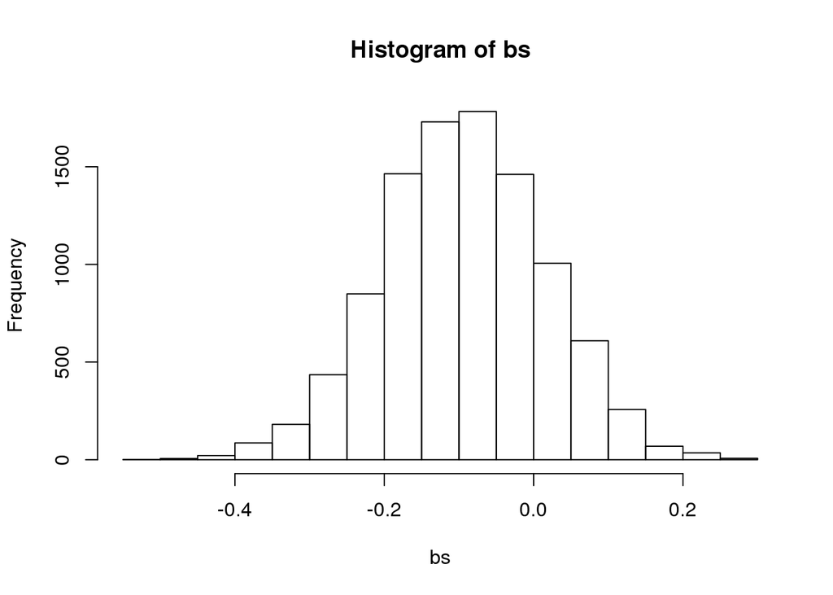

```r
#soda bootstrapping/confidence interval notes from thursday
sims <- 10000
bs <- numeric(sims)
for (i in 1:sims)
{
  west_coast <- mean(sample(0:1, size=26, replace=TRUE, prob=c(7/26, 19/26)))
  east_coast <- mean(sample(0:1, size=34, replace=TRUE, prob=c(6/34, 28/34)))

  bs[i] <- west_coast-east_coast
}

hist(bs)
```

```r
quantile(bs, prob=c(.025, .975))
```

```
##       2.5%      97.5%
## -0.3144796  0.1199095
```

funadmental question of inference – how does what you actually observe compare to what would happen if the null hypothesis were true, and you repeat the process many times?

probability of A intersect prob B has to = prob A * prob B if A and B are independent

```r
time <- c(30,25,20,18,21,22)
obs_stat <- mean(time[1:3]) - mean(time[4:6])
obs_stat
```

```
## [1] 4.666667
```

```r
#as fraction
MASS::fractions(obs_stat)
```

```
## [1] 14/3
```

```r
sims <- 10^4 - 1

#make answer vector
ans <- numeric(sims)

for(i in 1:sims)
{
  #returns 3 random vals between 1 and 6 without repeating
  index <- sample(6, 3, replace = FALSE)

  #puts 3 random vals from time into ans
    ans[i] <- mean(time[index]) - mean(time[-index])
}

pvalue <- (sum(ans >= obs_stat) + 1) / (sims + 1)
pvalue
```

```
## [1] 0.1513
```

if fail to reject null: the evidence fails to suggest there is a difference between the drug and control groups if reject null: the evidence suggests the mean time for a mouse on drugs is greater

```r
ans <- combn(time, 3)
ans
```

```
##      [,1] [,2] [,3] [,4] [,5] [,6] [,7] [,8] [,9] [,10] [,11] [,12] [,13]
## [1,]   30   30   30   30   30   30   30   30   30    30    25    25    25
## [2,]   25   25   25   25   20   20   20   18   18    21    20    20    20
## [3,]   20   18   21   22   18   21   22   21   22    22    18    21    22
##      [,14] [,15] [,16] [,17] [,18] [,19] [,20]
## [1,]    25    25    25    20    20    20    18
## [2,]    18    18    21    18    18    21    21
## [3,]    21    22    22    21    22    22    22
```

```r
avg_ans <- numeric(20)
for(i in 1:20)
{
   avg_ans[i] <- mean(ans[,i])
}
avg_ans
```

```
##  [1] 25.00000 24.33333 25.33333 25.66667 22.66667 23.66667 24.00000
##  [8] 23.00000 23.33333 24.33333 21.00000 22.00000 22.33333 21.33333
## [15] 21.66667 22.66667 19.66667 20.00000 21.00000 20.33333
```

```r
# loop through matrix
for (i in 1:nrow(matrix)) {
  for (j in 1:ncol(matrix)) {
    print(paste("On row", i, "and column", j, "the board contains", matrix[i, j]))
  }
}
```